# Lasso Regression with Boruta Feature Selection for Quantifying Coffee Adulteration: Spectral Preprocessing Using MSC, Savitzky-Golay, and Second Derivative

Author

Derick Malavi

## Introduction

Coffee adulteration, such as blending premium Arabica with lower-cost Robusta, undermines quality and authenticity, posing significant challenges for consumers, producers, and regulators. High-dimensional spectroscopic data provides valuable insights for detecting such fraud, but the large number of variables necessitates effective feature selection techniques to isolate the most relevant wavelengths.

This study incorporates the Boruta algorithm, a robust feature selection method that identifies relevant variables by iteratively comparing the importance of original features with randomized counterparts using a Random Forest framework. Boruta ensures the inclusion of critical spectral features while avoiding irrelevant or redundant variables, improving model interpretability and performance. Additionally, LASSO regression is employed as a feature selection and prediction method, shrinking irrelevant feature coefficients to zero and effectively handling multicollinearity while reducing the dataset’s dimensionality.

```r
# Load libraries
warning = FALSE
  suppressWarnings(suppressMessages({
  library(caret)
  library(GA)
  library(glmnet)
  library(viridis)
  library(Boruta)
  library(ggplot2)
  library(dplyr)
  library(readxl)
  library(readr)
  library(janitor)
  library(class)
  library(MLmetrics)
  library(MLeval)
  library(themis)
  library(ROSE)
  library(parallel)
  library(doParallel)
  library(foreach)
  library(pheatmap)
  library(mdatools)
  library(nnet)
  library(DMwR)
  library(e1071)
  library(knitr)
  library(pROC)
  library(gridExtra)
  library(FactoMineR)
  library(doSNOW)
  library(MASS)
  library(factoextra)
  library(kernlab)}))
```

## Prepare Data

```r
# Load data: msc_sg_2d spectra

hsi_msc_sg_2d <- read.csv("coffee_ground_msc_sg_2d.csv")

# Ensure we have the same number of dimensions and the range of our columns/covariates
dim(hsi_msc_sg_2d)
```

```
[1] 1469  229
```

```r
# Check a few column names
col_check <- colnames(hsi_msc_sg_2d[,c(1:6)])
col_check
```

```
[1] "sample_id"     "binary_class"  "three_class"   "adult_percent"
[5] "cal_val"       "X935.609985"
```

```r
# our response variable (adulteration percentage) is column 4
# The spectral values start from column # 6 -------> 229

# Convert the adulteration percentage to numeric for compatibility with ML
hsi_msc_sg_2d$adult_percent <- as.numeric(hsi_msc_sg_2d$adult_percent)
```

## Get the X and y variables

```r
X <- hsi_msc_sg_2d[,c(6:229)]
y <- hsi_msc_sg_2d[,4]

class(y) #Ensure y (target variable) is a numeric for regression
```

```
[1] "numeric"
```

## Visualize X

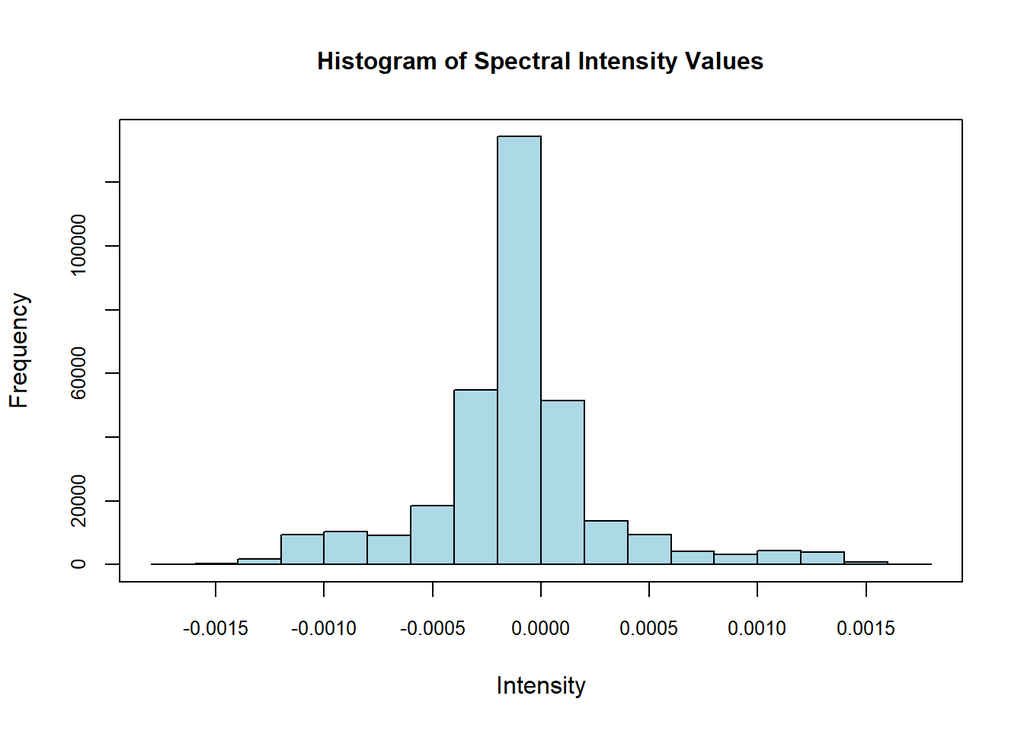

```r
hist(as.matrix(X), col = 'lightblue', cex.main = 1.0, cex.axis = 0.8,cex.lab = 1.0,
     main = 'Histogram of Spectral Intensity Values', xlab = 'Intensity'); box()
```

## Split the Data (Train_Test Split)

- We want to select features based on training data only to avoid any data leakage that could inflate model performance and make the model less generalizable to unseen data.

```r
# Subset samples for cross-validation and external validation (70/30)
# Record 1 under cal_val variable is for calibration while 2 will be for testing the model

sample<-hsi_msc_sg_2d$cal_val == 1

# Split to train and test sets
X_train <- X[sample,]
X_test <- X[!sample,]
y_train <-y[sample]
y_test <- y[!sample]

# Check length of the subsets for training and validation
dim(X_train)
```

```
[1] 1055  224
```

```r
dim(X_test)
```

```
[1] 414 224
```

```r
length(y_train)
```

```
[1] 1055
```

```r
length(y_test)
```

```
[1] 414
```

```r
# Merge the test and train data
train_data <- data.frame(X_train, y_train)
test_data <- data.frame(X_test, y_test)
```

## Run Boruta Algorithm for Optimum Wavelength Selection

```r
  # Set seed for reproducibility
  set.seed(123)

  # Set the dataset name dynamically
  dataset_name <- "msc_sg_2d"

  # Define paths for the execution flag and Boruta result
  flag_file <- paste0("boruta_executed_flag_", dataset_name, ".RData")
  result_file <- paste0("boruta_result_", dataset_name, ".RData")

  # Register cluster for caret to train the models in parallel
  cl <- makeCluster(6, type = "SOCK")
  suppressWarnings(suppressMessages(registerDoSNOW(cl)))

if (!file.exists(result_file)) {
  message(paste("Starting Boruta execution for dataset:", dataset_name))

  # Start the timer
  start_time <- Sys.time()

  # Run Boruta on the train data set
  boruta_result <- Boruta(formula = y_train ~ .,
                        data = train_data,
                        doTrace = 2,
                        maxRuns = 100)

  # Stop the cluster
  stopCluster(cl)

  # Register end time
  end_time <- Sys.time()
  print(paste('Time to run the Boruta model:', end_time - start_time))

  # Save Boruta results and execution flag
  boruta_executed <- TRUE
  save(boruta_executed, file = flag_file)
  save(boruta_result, file = result_file)


  message(paste("Boruta execution completed for dataset:", dataset_name, "and results saved."))

} else {
  # Load previously saved results
  message(paste("Result file found. Loading saved Boruta results for dataset:", dataset_name))
  load(result_file)
  load(flag_file)
  message(paste("Boruta already executed for dataset:", dataset_name))
}
```

```
Result file found. Loading saved Boruta results for dataset: msc_sg_2d
```

```
Boruta already executed for dataset: msc_sg_2d
```

```r
# Print Boruta summary
print(boruta_result)
```

```
Boruta performed 99 iterations in 5.64418 mins.
 202 attributes confirmed important: X1001.369995, X1004.830017,
X1008.299988, X1011.77002, X1015.23999 and 197 more;
 No attributes deemed unimportant.
 22 tentative attributes left: X1049.949951, X1056.900024,
X1060.380005, X1070.810059, X1329.699951 and 17 more;
```

```r
# Get selected features
final_features <- getSelectedAttributes(boruta_result, withTentative = FALSE)
final_features
```

```
  [1] "X973.650024"  "X977.109985"  "X980.580017"  "X984.039978"  "X987.51001"
  [6] "X997.900024"  "X1001.369995" "X1004.830017" "X1008.299988" "X1011.77002"
 [11] "X1015.23999"  "X1018.710022" "X1022.179993" "X1025.650024" "X1029.119995"
 [16] "X1032.589966" "X1036.060059" "X1039.530029" "X1043"        "X1046.47998"
 [21] "X1053.430054" "X1063.849976" "X1067.329956" "X1074.290039" "X1077.76001"
 [26] "X1081.23999"  "X1084.719971" "X1088.199951" "X1091.680054" "X1095.170044"
 [31] "X1098.650024" "X1102.130005" "X1105.609985" "X1109.099976" "X1112.579956"
 [36] "X1116.069946" "X1119.550049" "X1123.040039" "X1126.52002"  "X1130.01001"
 [41] "X1133.5"      "X1136.98999"  "X1140.469971" "X1143.959961" "X1147.449951"
 [46] "X1150.939941" "X1154.430054" "X1157.930054" "X1161.420044" "X1164.910034"
 [51] "X1168.400024" "X1171.900024" "X1175.390015" "X1178.890015" "X1182.380005"
 [56] "X1185.880005" "X1189.369995" "X1192.869995" "X1196.369995" "X1199.869995"
 [61] "X1203.369995" "X1206.869995" "X1210.369995" "X1213.869995" "X1217.369995"
 [66] "X1220.869995" "X1224.369995" "X1227.869995" "X1231.380005" "X1234.880005"
 [71] "X1238.390015" "X1241.890015" "X1245.400024" "X1248.900024" "X1252.410034"
```

[output cut: 26 more lines]

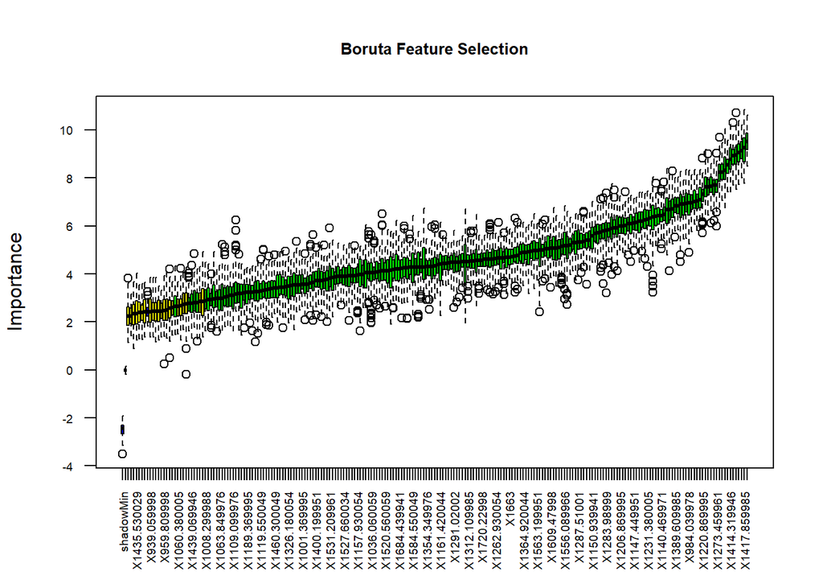

```r
# Plot Boruta results
plot(boruta_result, xlab = "", las = 2,
     cex.main = 0.8, cex.axis = 0.6,
     main = paste("Boruta Feature Selection"))
```

```r
print(paste('The number of selected variables are', length(final_features)))
```

```
[1] "The number of selected variables are 202"
```

## Create a Data frame with the Selected Features

```r
# Subset the training and test data using the selected features
X_train_selected <- X_train[, final_features]
X_test_selected <- X_test[, final_features]

# Keep y_train and y_test as-is
y_train_selected <- y_train
y_test_selected <- y_test


#Merge data_frame
train_merged <- cbind(X_train_selected, y_train = y_train_selected)
test_merged <- cbind(X_test_selected, y_test = y_test_selected)

dim(train_merged)
```

```
[1] 1055  203
```

```r
dim(test_merged)
```

```
[1] 414 203
```

## Check correlations by HeatMaps

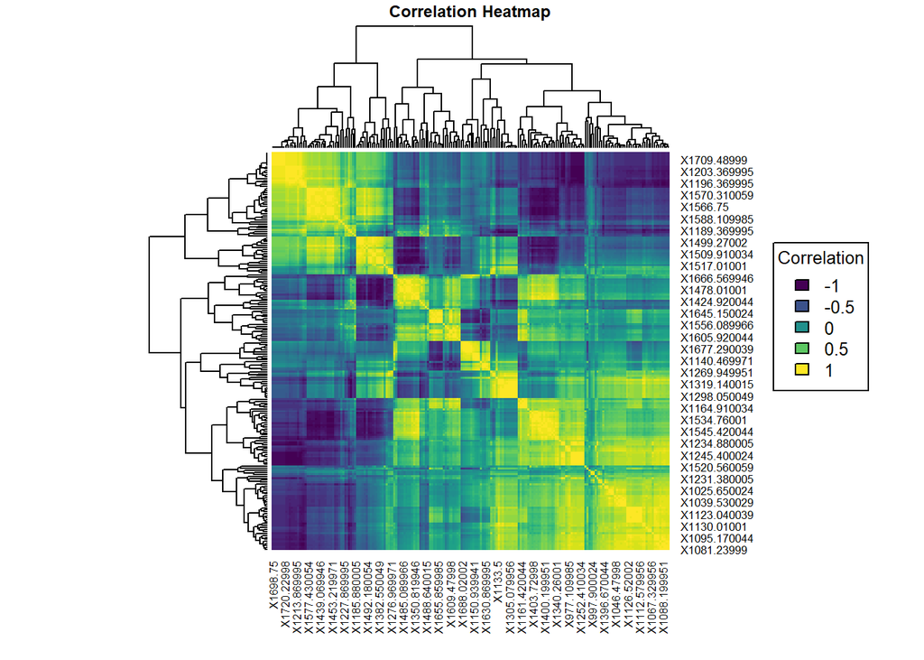

```r
n_features <- length(final_features)

#Calculate correlations
corr <- cor(train_merged[, -(n_features+1)])

# Create a heat map
par(cex.main = 0.6)
heatmap(corr, symm = TRUE,
        col = viridis(50),
        main = "Correlation Heatmap")

# Add legend

legend("right",
       legend = seq(-1, 1, by = 0.5),  # Correlation range
       fill = viridis(5),
       title = "Correlation", cex = 0.8)
```

## Train Models

- We will train models based on the reduced number of features.

```r
# Set random seed for reproducibility
set.seed (123)

# Set up the training control(10 folds 10 times cross_validation)
control <- trainControl(method = "repeatedcv", number = 10, repeats = 10,
                        savePredictions = "final",
                        summaryFunction = defaultSummary,
                        selectionFunction = 'best', allowParallel = TRUE)

# We used oneSE for classification. For regression, we will use 'best': a model that minimizes RMSECV
```

```r
#Set the metric as accuracy
metric<-"RMSE"
```

```r
# Hyperparameter set
# alpha: Set to 1 for LASSO (pure L1 regularization).
# lambda: Regularization strength (penalty parameter). A sequence of values is tested to identify the best lambda.

grid <- expand.grid(
  alpha = 1,   # LASSO (alpha = 1)
  lambda = seq(0.001, 0.1, length = 10)
)
```

# Train Lasso

```r
set.seed(123)
#Register cluster for caret to train the models in parallel
cl<-makeCluster(6,type = "SOCK")
suppressWarnings(suppressMessages(
  registerDoSNOW(cl)))

# Start_time
start_time<-Sys.time()

#Train the model using cross-validation (10 folds, 10 times)
fit_lasso_msc_sg_2d<-train(y = train_merged[,(n_features+1)],
                         x = train_merged[,-(n_features+1)],
                         method = 'glmnet', tuneGrid = grid,
                         trControl = control, preProcess = c("center","scale"),
                         metric = metric)
#End_time
end_time<-Sys.time()

model_training_time<-end_time-start_time

stopCluster(cl) # Stop the parallel run cluster

print(model_training_time)
```

```
Time difference of 23.20398 secs
```

```r
# Display regression results
print(fit_lasso_msc_sg_2d)
```

```
glmnet

1055 samples
 202 predictor

Pre-processing: centered (202), scaled (202)
Resampling: Cross-Validated (10 fold, repeated 10 times)
Summary of sample sizes: 949, 949, 949, 948, 949, 950, ...
Resampling results across tuning parameters:

  lambda  RMSE      Rsquared   MAE
  0.001   6.039578  0.9567739  4.752089
  0.012   6.203143  0.9544109  4.882473
  0.023   6.419649  0.9511954  5.050829
  0.034   6.607337  0.9482933  5.190831
  0.045   6.788841  0.9453988  5.330543
  0.056   6.946002  0.9428323  5.450313
  0.067   7.064868  0.9408534  5.543355
  0.078   7.171563  0.9390528  5.633791
  0.089   7.278150  0.9372243  5.729924
  0.100   7.355032  0.9358955  5.799442

Tuning parameter 'alpha' was held constant at a value of 1
RMSE was used to select the optimal model using the smallest value.
The final values used for the model were alpha = 1 and lambda = 0.001.
```

#### Best hyperparameters

```r
# Best lambda value
best_lambda <- fit_lasso_msc_sg_2d$bestTune$lambda

cat("Best Lambda:", best_lambda, "\n")
```

```
Best Lambda: 0.001
```

#### Extract Selected Features

```r
# Extract coefficients from the best model
coefficients <- coef(fit_lasso_msc_sg_2d$finalModel, s = best_lambda)

# Convert to a readable format
lasso_coefficients <- as.data.frame(as.matrix(coefficients))
colnames(lasso_coefficients) <- "Coefficient"
lasso_coefficients$Variable <- rownames(lasso_coefficients)

# Filter non-zero coefficients (selected features)
selected_features <- lasso_coefficients[lasso_coefficients$Coefficient != 0, ]
print(selected_features)
```

```
               Coefficient     Variable
(Intercept)   3.016019e+01  (Intercept)
X973.650024   3.348877e+00  X973.650024
X977.109985  -2.130849e+00  X977.109985
X980.580017   7.791291e-01  X980.580017
X984.039978   3.900373e-03  X984.039978
X987.51001    5.565766e-02   X987.51001
X997.900024   9.822718e-02  X997.900024
X1001.369995 -7.413788e-01 X1001.369995
X1004.830017  9.212127e-01 X1004.830017
X1011.77002  -6.016201e-01  X1011.77002
X1015.23999   3.197826e+00  X1015.23999
X1018.710022 -5.269344e-01 X1018.710022
X1022.179993 -1.741102e+00 X1022.179993
X1029.119995  3.802688e+00 X1029.119995
X1032.589966  8.928423e-04 X1032.589966
X1036.060059 -4.386660e-02 X1036.060059
X1039.530029  3.511333e+00 X1039.530029
X1043         2.208345e+00        X1043
X1046.47998  -1.622361e+00  X1046.47998
X1053.430054  3.029319e+00 X1053.430054
X1067.329956 -1.638766e+00 X1067.329956
X1081.23999   2.524631e+00  X1081.23999
X1088.199951 -7.480612e-01 X1088.199951
X1091.680054 -4.410758e+00 X1091.680054
X1098.650024  6.648359e+00 X1098.650024
X1109.099976  1.832335e+00 X1109.099976
X1112.579956  2.029753e-01 X1112.579956
X1126.52002   1.569845e+01  X1126.52002
X1130.01001   3.260389e-01  X1130.01001
X1136.98999   7.154288e-02  X1136.98999
X1140.469971  3.626582e+00 X1140.469971
X1143.959961  3.881565e+00 X1143.959961
X1147.449951  1.335286e+00 X1147.449951
X1168.400024  9.084991e-01 X1168.400024
X1171.900024  1.004376e+00 X1171.900024
X1175.390015  1.263906e+00 X1175.390015
X1178.890015  3.447994e+00 X1178.890015
X1182.380005  3.265648e+00 X1182.380005
X1192.869995 -3.451111e+00 X1192.869995
```

[output cut: 82 more lines]

```
X1623.73999   2.511140e+00  X1623.73999
X1627.310059 -2.708352e-01 X1627.310059
X1634.439941 -1.250573e+01 X1634.439941
X1641.579956  5.353203e+00 X1641.579956
X1645.150024  8.036477e+00 X1645.150024
X1652.290039 -1.367928e+01 X1652.290039
X1659.430054 -3.637134e+00 X1659.430054
X1666.569946  7.380667e+00 X1666.569946
X1670.140015  1.347129e+01 X1670.140015
X1680.869995 -1.169456e-01 X1680.869995
X1684.439941 -1.103082e-01 X1684.439941
X1688.02002  -5.912826e+00  X1688.02002
X1698.75     -1.864660e+00     X1698.75
X1702.329956 -4.095606e-11 X1702.329956
X1705.910034 -2.026539e-11 X1705.910034
```

```r
# Sort the selected features by actual values in descending order
selected_features_sorted_actual <- selected_features[order(selected_features$Coefficient, decreasing = TRUE), ]

# Print the sorted features
print(selected_features_sorted_actual)
```

```
               Coefficient     Variable
(Intercept)   3.016019e+01  (Intercept)
X1336.73999   1.650153e+01  X1336.73999
X1439.069946  1.616093e+01 X1439.069946
X1126.52002   1.569845e+01  X1126.52002
X1442.599976  1.537823e+01 X1442.599976
X1400.199951  1.391723e+01 X1400.199951
X1670.140015  1.347129e+01 X1670.140015
X1361.390015  1.242391e+01 X1361.390015
X1343.780029  1.102764e+01 X1343.780029
X1645.150024  8.036477e+00 X1645.150024
X1602.349976  7.834232e+00 X1602.349976
X1666.569946  7.380667e+00 X1666.569946
X1573.869995  6.935256e+00 X1573.869995
X1545.420044  6.903612e+00 X1545.420044
X1098.650024  6.648359e+00 X1098.650024
X1301.560059  6.570431e+00 X1301.560059
X1357.869995  5.667855e+00 X1357.869995
X1641.579956  5.353203e+00 X1641.579956
X1492.180054  4.553408e+00 X1492.180054
X1287.51001   3.916113e+00  X1287.51001
X1143.959961  3.881565e+00 X1143.959961
X1029.119995  3.802688e+00 X1029.119995
X1140.469971  3.626582e+00 X1140.469971
X1039.530029  3.511333e+00 X1039.530029
X1178.890015  3.447994e+00 X1178.890015
X973.650024   3.348877e+00  X973.650024
X1182.380005  3.265648e+00 X1182.380005
X1015.23999   3.197826e+00  X1015.23999
X1053.430054  3.029319e+00 X1053.430054
X1595.22998   2.990666e+00  X1595.22998
X1620.170044  2.879627e+00 X1620.170044
X1224.369995  2.593367e+00 X1224.369995
X1081.23999   2.524631e+00  X1081.23999
X1623.73999   2.511140e+00  X1623.73999
X1043         2.208345e+00        X1043
X1273.459961  1.984287e+00 X1273.459961
X1298.050049  1.863529e+00 X1298.050049
X1109.099976  1.832335e+00 X1109.099976
X1563.199951  1.711931e+00 X1563.199951
```

[output cut: 82 more lines]

```
X1580.98999  -5.317299e+00  X1580.98999
X1527.660034 -5.441101e+00 X1527.660034
X1688.02002  -5.912826e+00  X1688.02002
X1393.140015 -6.151555e+00 X1393.140015
X1577.430054 -6.373227e+00 X1577.430054
X1319.140015 -7.084203e+00 X1319.140015
X1609.47998  -7.456864e+00  X1609.47998
X1245.400024 -7.574129e+00 X1245.400024
X1227.869995 -7.891750e+00 X1227.869995
X1382.550049 -9.037017e+00 X1382.550049
X1538.319946 -1.235133e+01 X1538.319946
X1238.390015 -1.240089e+01 X1238.390015
X1634.439941 -1.250573e+01 X1634.439941
X1252.410034 -1.348168e+01 X1252.410034
X1652.290039 -1.367928e+01 X1652.290039
```

```r
print(paste('The number of feautures selected by Lasso are', nrow(selected_features_sorted_actual)))
```

```
[1] "The number of feautures selected by Lasso are 136"
```

## Save the models for future use

```r
saveRDS(fit_lasso_msc_sg_2d, "fit_lasso_msc_sg_2d.rds")
```

## Plot the cross-validation results —–> Model Selection

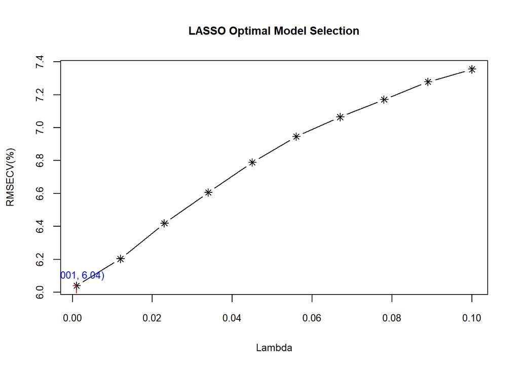

```r
# Extract results and best lambda
lasso_data <- fit_lasso_msc_sg_2d$results
best_lambda <- fit_lasso_msc_sg_2d$bestTune$lambda
y_RMSE <- lasso_data$RMSE[lasso_data$lambda == best_lambda]

# Plot RMSE against lambda
plot(
  lasso_data$lambda, lasso_data$RMSE, type = "b", col = "black", pch = 8, cex.axis = 0.8,
  xlab = "Lambda", ylab = "RMSECV(%)", cex.lab = 0.9,
  main = "LASSO Optimal Model Selection", cex.main = 0.9, cex.lab = 0.8
)

# Add line from x-axis to the specific point (optimal lambda)
segments(x0 = best_lambda, y0 = 0, x1 = best_lambda, y1 = y_RMSE, col = "red", lty = 2)

# Add line from y-axis to the specific point (corresponding RMSE)
segments(x0 = 0, y0 = y_RMSE, x1 = best_lambda, y1 = y_RMSE, col = "red", lty = 2)

# Add annotation for the optimal point
text(best_lambda, y_RMSE, labels = paste0("(", round(best_lambda, 4), ", ", round(y_RMSE, 2), ")"),
     pos = 3, col = "blue", cex = 0.8)
```

#### Coefficients vs. Lambda Path

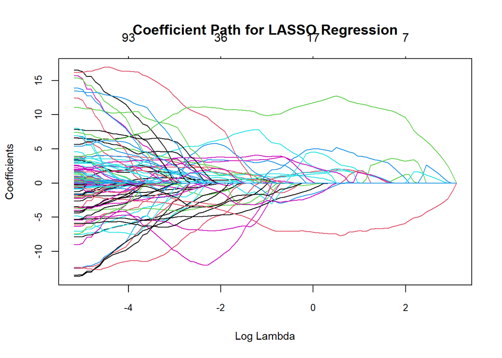

```r
# Extract the final glmnet model
fit_glmnet <- fit_lasso_msc_sg_2d$finalModel

# Plot coefficients vs. lambda
plot(
  fit_glmnet,
  xvar = "lambda",
  label = FALSE,
  cex.axis = 0.8,
  cex.lab = 0.9,
  cex.main = 0.3)
title(main = "Coefficient Path for LASSO Regression")
```

```r
#As lambda increases, coefficients shrink toward zero, highlighting the feature selection process
```

## Display CV Results in Tables

```r
kable(fit_lasso_msc_sg_2d$results)
```

| alpha | lambda | RMSE | Rsquared | MAE | RMSESD | RsquaredSD | MAESD |
| --- | --- | --- | --- | --- | --- | --- | --- |
| 1 | 0.001 | 6.039578 | 0.9567739 | 4.752089 | 0.4128476 | 0.0056547 | 0.3444115 |
| 1 | 0.012 | 6.203144 | 0.9544109 | 4.882473 | 0.4406963 | 0.0060928 | 0.3628570 |
| 1 | 0.023 | 6.419649 | 0.9511954 | 5.050829 | 0.4640348 | 0.0065086 | 0.3752415 |
| 1 | 0.034 | 6.607337 | 0.9482933 | 5.190831 | 0.4852378 | 0.0068855 | 0.3886656 |
| 1 | 0.045 | 6.788841 | 0.9453988 | 5.330543 | 0.5029938 | 0.0072745 | 0.4011554 |
| 1 | 0.056 | 6.946002 | 0.9428323 | 5.450313 | 0.5191053 | 0.0075952 | 0.4134460 |
| 1 | 0.067 | 7.064868 | 0.9408534 | 5.543355 | 0.5294427 | 0.0078166 | 0.4216178 |
| 1 | 0.078 | 7.171563 | 0.9390528 | 5.633790 | 0.5416217 | 0.0080477 | 0.4263812 |
| 1 | 0.089 | 7.278150 | 0.9372243 | 5.729924 | 0.5576261 | 0.0083439 | 0.4338193 |
| 1 | 0.100 | 7.355032 | 0.9358955 | 5.799442 | 0.5704764 | 0.0085739 | 0.4381155 |

```r
# Select row for the optimal model
opt_row <- fit_lasso_msc_sg_2d$results %>%
  filter(lambda==fit_lasso_msc_sg_2d$bestTune$lambda)

kable(opt_row)
```

| alpha | lambda | RMSE | Rsquared | MAE | RMSESD | RsquaredSD | MAESD |
| --- | --- | --- | --- | --- | --- | --- | --- |
| 1 | 0.001 | 6.039578 | 0.9567739 | 4.752089 | 0.4128476 | 0.0056547 | 0.3444115 |

## Test the model performance on test data

```r
#Predict on the test set
observed <- test_merged$y_test
predictions <- predict(fit_lasso_msc_sg_2d,newdata=test_merged)

# Generate predictions
results <- postResample(predictions, observed)

print(results)
```

```
     RMSE  Rsquared       MAE
8.0145267 0.9320889 6.4052678
```

```r
RMSEP = results[[1]]
R2 = results[[2]]
MAE = results[[3]]

cat('The RMSEP for the model on external validation is:', RMSEP,'\n')
```

```
The RMSEP for the model on external validation is: 8.014527
```

```r
cat('The R Squared value for the model is:', R2)
```

```
The R Squared value for the model is: 0.9320889
```

```r
# Calculate Residual Predictive Deviation to check model performance

RPD = sd(observed)/RMSEP

print(paste('The RPD values for the model is', round(RPD,2)))
```

```
[1] "The RPD values for the model is 3.63"
```

## Visualizations

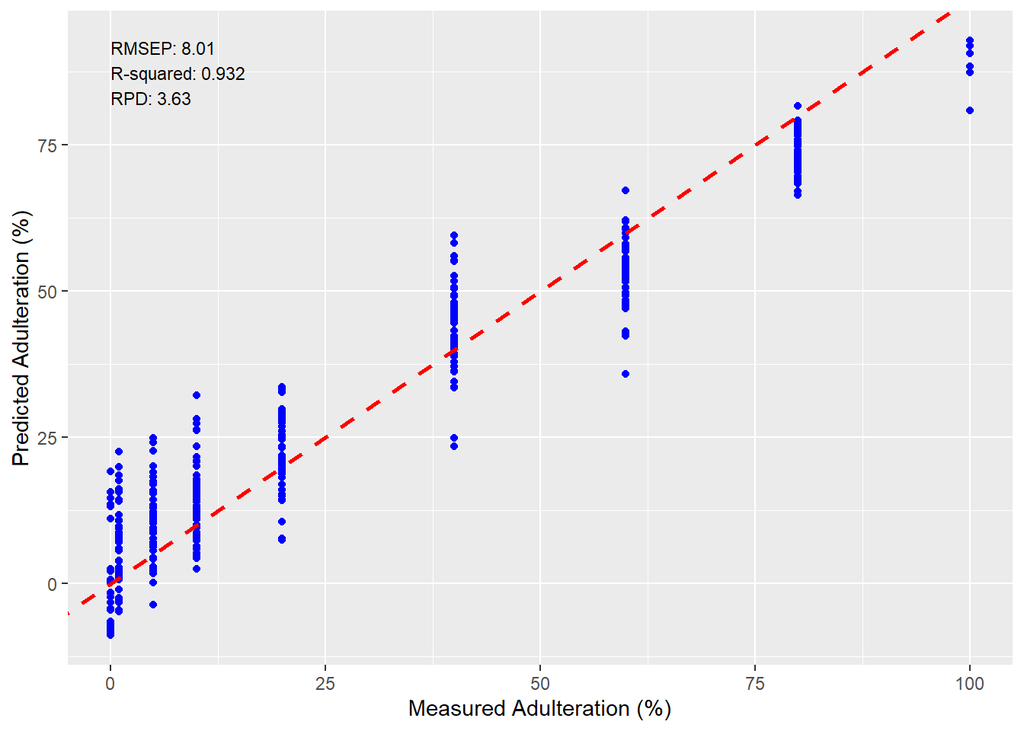

```r
# predicted vs observed line and scatter
# Create a data frame
results_df <- data.frame(observed=observed, predictions=predictions)

results_df %>%
  ggplot(aes(x = observed, y = predictions)) +
  geom_point(color = "blue") +
  geom_abline(slope = 1, intercept = 0, color = "red",
              linetype = "dashed", linewidth = 1) +
  labs( x = "Measured Adulteration (%)",
    y = "Predicted Adulteration (%)") +
  annotate("text",
    x = min(observed), y = max(predictions),
    label = paste("RMSEP:", round(RMSEP, 2),
      "\nR-squared:", round(R2, 3),
      "\nRPD:", round(RPD, 2)),
    hjust = 0, vjust = 1, size = 3, color = "black") +
  theme(
    axis.title = element_text(color = "black", size = 10),
    axis.text = element_text(color = "black"))+
  theme_gray()
```

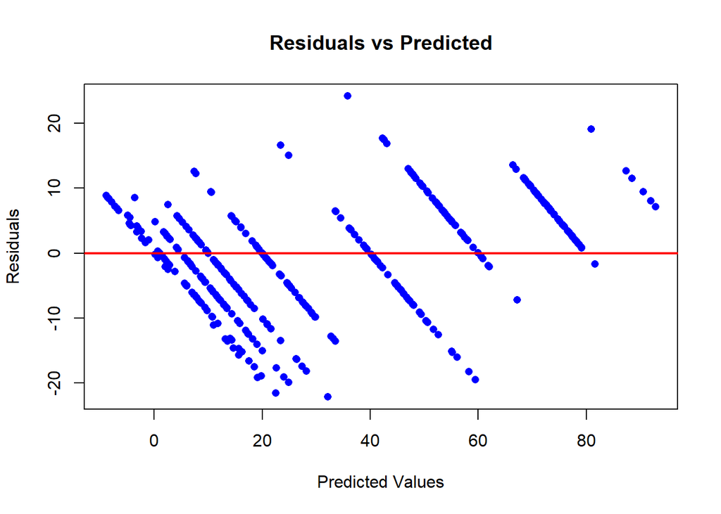

```r
# Check residuals

residuals <- observed - predictions

# Plot Residuals
plot(predictions, residuals,
     xlab = "Predicted Values",
     ylab = "Residuals",
     main = "Residuals vs Predicted",
     pch = 16, col = "blue")
abline(h = 0, col = "red", lwd = 2)
```

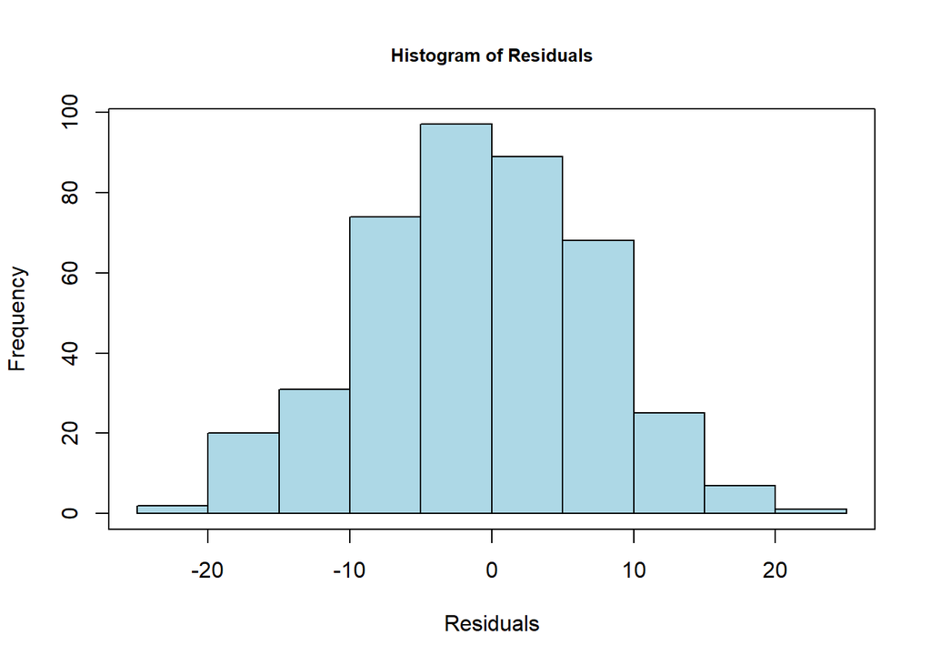

```r
hist(residuals,
     main = "Histogram of Residuals",
     xlab = "Residuals", cex.main = 0.8,
     col = "lightblue", border = "black"); box()
```

## Conclusion

- Boruta algorithm and lasso demonstrate excellent performance in predicting adulteration in ground coffee. The model achieves an RPD value of 3.6. The model is highly accurate and reliable for analytical and quantitative applications.